# Poisson Regression Examples

Author

Puja Malik

Published

May 27, 2025

## 1 Blueprinty Case Study

### 1.1 Introduction

Blueprinty is a small firm that makes software for developing blueprints specifically for submitting patent applications to the US patent office. Their marketing team would like to make the claim that patent applicants using Blueprinty’s software are more successful in getting their patent applications approved. Ideal data to study such an effect might include the success rate of patent applications before using Blueprinty’s software and after using it. Unfortunately, such data is not available.

However, Blueprinty has collected data on 1,500 mature (non-startup) engineering firms. The data include each firm’s number of patents awarded over the last 5 years, regional location, age since incorporation, and whether or not the firm uses Blueprinty’s software. The marketing team would like to use this data to make the claim that firms using Blueprinty’s software are more successful in getting their patent applications approved.

### 1.2 Data

```
           patents          age   iscustomer
count  1500.000000  1500.000000  1500.000000
mean      3.684667    26.357667     0.320667
std       2.352500     7.242528     0.466889
min       0.000000     9.000000     0.000000
25%       2.000000    21.000000     0.000000
50%       3.000000    26.000000     0.000000
75%       5.000000    31.625000     1.000000
max      16.000000    49.000000     1.000000
```

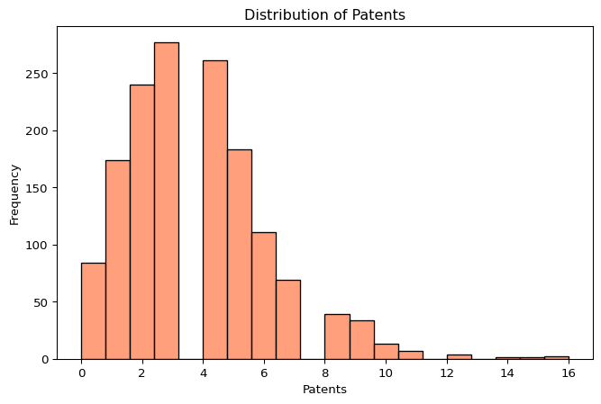

## 2 Data Exploration

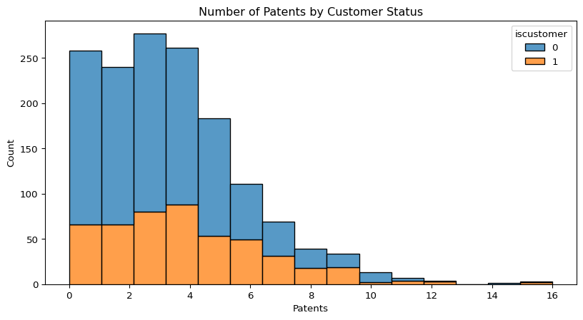

[output not shown]

We observe that Blueprinty customers tend to have a higher mean number of patents compared to non-customers. However, since customers are not selected at random, it’s important to account for other systematic differences—such as age and regional location—before attributing differences in patent output to Blueprinty usage.

Blueprinty customers are not selected at random. It may be important to account for systematic differences in the age and regional location of customers vs non-customers.

```
Mean number of patents by customer status:
iscustomer
0    3.473013
1    4.133056
Name: patents, dtype: float64
Region distribution by customer status:
region      Midwest  Northeast  Northwest  South  Southwest
iscustomer
0               187        273        158    156        245
1                37        328         29     35         52
```

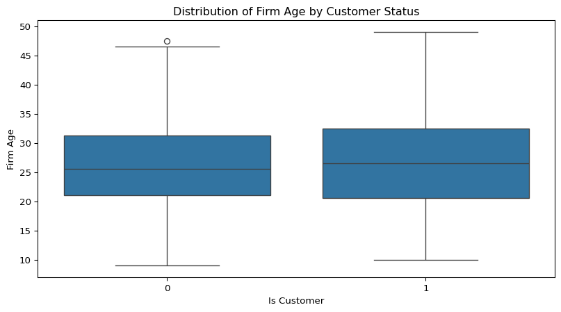

We observe that Blueprinty customers may differ systematically in terms of geographic region and firm age. These differences should be accounted for in the regression analysis to avoid biased estimates of the effect of using Blueprinty’s software.

### 2.1 Estimation of Simple Poisson Model

Since our outcome variable of interest can only be small integer values per a set unit of time, we can use a Poisson density to model the number of patents awarded to each engineering firm over the last 5 years. We start by estimating a simple Poisson model via Maximum Likelihood.

The probability mass function for the Poisson distribution is:

$$f(Y | \lambda) = \frac{e^{-\lambda} \lambda^Y}{Y!}$$

Assuming observations are independent, the likelihood function for a sample of (n) firms is:

$$L(\lambda) = \prod_{i=1}^{n} \frac{e^{-\lambda_i} \lambda_i^{y_i}}{y_i!}$$

Taking the logarithm yields the log-likelihood:

$$\ell(\lambda) = \sum_{i=1}^{n} \left( -\lambda_i + y_i \log(\lambda_i) - \log(y_i!) \right)$$

### 2.2 Poisson Likelihood Model

Since our outcome variable of interest can only be small integer values per a set unit of time, we can use a Poisson density to model the number of patents awarded to each engineering firm over the last 5 years. We start by estimating a simple Poisson model via Maximum Likelihood.

The probability mass function for the Poisson distribution is:

$$f(Y | \lambda) = \frac{e^{-\lambda} \lambda^Y}{Y!}$$

Assuming observations are independent, the likelihood function for a sample of ( n ) firms is:

$$L(\lambda) = \prod_{i=1}^{n} \frac{e^{-\lambda_i} \lambda_i^{y_i}}{y_i!}$$

Taking the logarithm yields the log-likelihood:

$$\ell(\lambda) = \sum_{i=1}^{n} \left( -\lambda_i + y_i \log(\lambda_i) - \log(y_i!) \right)$$

```python
def poisson_loglikelihood(lambda_, Y):
    from scipy.special import gammaln
    return np.sum(-lambda_ + Y * np.log(lambda_) - gammaln(Y + 1))
```

[figure not shown]

$$\hat{\lambda}_{\text{MLE}} = \bar{Y}$$

```
MLE for lambda: 3.6846666675617414
```

### 2.3 Estimation of Poisson Regression Model

Next, we extend our simple Poisson model to a Poisson Regression Model such that $Y_i = \text{Poisson}(\lambda_i)$ where $\lambda_i = \exp(X_i'\beta)$. The interpretation is that the success rate of patent awards is not constant across all firms ($\lambda$) but rather is a function of firm characteristics $X_i$. Specifically, we will use the covariates age, age squared, region, and whether the firm is a customer of Blueprinty.

```
Optimization failed: Desired error not necessarily achieved due to precision loss.
MLE Estimates, Standard Errors, z-values, and p-values:
                  Coefficient  Std. Error        z  p-value
const                 -0.5089      0.1857  -2.7410   0.0061
age_scaled             1.4862      0.1392  10.6759   0.0000
age_squared           -0.2970      0.0258 -11.4956   0.0000
iscustomer             0.2076      0.0322   6.4489   0.0000
region_Northeast       0.0292      0.0461   0.6330   0.5267
region_Northwest      -0.0176      0.0557  -0.3158   0.7522
region_South           0.0566      0.0546   1.0356   0.3004
region_Southwest       0.0506      0.0481   1.0511   0.2932
```

```
                 Generalized Linear Model Regression Results
==============================================================================
Dep. Variable:                patents   No. Observations:                 1500
Model:                            GLM   Df Residuals:                     1492
Model Family:                 Poisson   Df Model:                            7
Link Function:                    Log   Scale:                          1.0000
Method:                          IRLS   Log-Likelihood:                -3258.1
Date:                Sat, 10 May 2025   Deviance:                       2143.3
Time:                        23:29:59   Pearson chi2:                 2.07e+03
No. Iterations:                     5   Pseudo R-squ. (CS):             0.1360
Covariance Type:            nonrobust
====================================================================================
                       coef    std err          z      P>|z|      [0.025      0.975]
------------------------------------------------------------------------------------
const               -0.5089      0.183     -2.778      0.005      -0.868      -0.150
age_scaled           1.4862      0.139     10.716      0.000       1.214       1.758
age_squared         -0.2970      0.026    -11.513      0.000      -0.348      -0.246
iscustomer           0.2076      0.031      6.719      0.000       0.147       0.268
region_Northeast     0.0292      0.044      0.669      0.504      -0.056       0.115
region_Northwest    -0.0176      0.054     -0.327      0.744      -0.123       0.088
region_South         0.0566      0.053      1.074      0.283      -0.047       0.160
region_Southwest     0.0506      0.047      1.072      0.284      -0.042       0.143
====================================================================================
```

## 3 Predicted vs Actual Patents Plot

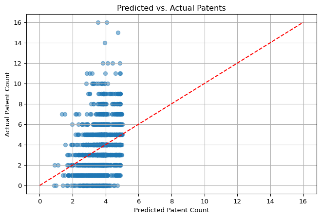

## 4 Customer Effect Simulation

To interpret the effect of Blueprinty’s software, we simulate predictions under two scenarios:

All firms as non-customers (iscustomer = 0)

All firms as customers (iscustomer = 1)

We then compare the average predicted patent count across the two.

```
Average difference in predicted patents from using Blueprinty's software: 0.7928
```

### 4.1 Interpretation and Insights

To interpret the practical effect of Blueprinty’s software, we simulated two scenarios: one where all firms were set as non-customers and one where all were set as customers. Using our fitted Poisson model, we predicted the number of patents for each firm under both conditions. The average difference in predicted patents—comparing the customer scenario to the non-customer scenario—provides an interpretable estimate of Blueprinty’s impact.

## 5 AirBnB Case Study

### 5.1 Introduction

This helps us understand the factors that drive demand for Airbnb listings in New York City.

```
count    40628.000000
mean        15.904426
std         29.246009
min          0.000000
25%          1.000000
50%          4.000000
75%         17.000000
max        421.000000
Name: number_of_reviews, dtype: float64
```

**Variable Definitions**

```
- `id` = unique ID number for each unit
- `last_scraped` = date when information scraped
- `host_since` = date when host first listed the unit on Airbnb
- `days` = `last_scraped` - `host_since` = number of days the unit has been listed
- `room_type` = Entire home/apt., Private room, or Shared room
- `bathrooms` = number of bathrooms
- `bedrooms` = number of bedrooms
- `price` = price per night (dollars)
- `number_of_reviews` = number of reviews for the unit on Airbnb
- `review_scores_cleanliness` = a cleanliness score from reviews (1-10)
- `review_scores_location` = a "quality of location" score from reviews (1-10)
- `review_scores_value` = a "quality of value" score from reviews (1-10)
- `instant_bookable` = "t" if instantly bookable, "f" if not
```

## 6 Exploratory Analysis and Modeling Strategy

We treat the number of reviews as a proxy for the number of bookings. Since this is a count variable, a Poisson regression model is well-suited for capturing its relationship with various listing characteristics. Our approach includes:

Conducting exploratory data analysis to understand distributions and identify missing values.

Filtering or imputing missing observations as needed.

Interpreting the model coefficients to understand how each variable influences the expected number of bookings.

This helps us understand the factors that drive demand for Airbnb listings in New York City.

```
count    40628.000000
mean        15.904426
std         29.246009
min          0.000000
25%          1.000000
50%          4.000000
75%         17.000000
max        421.000000
Name: number_of_reviews, dtype: float64
```

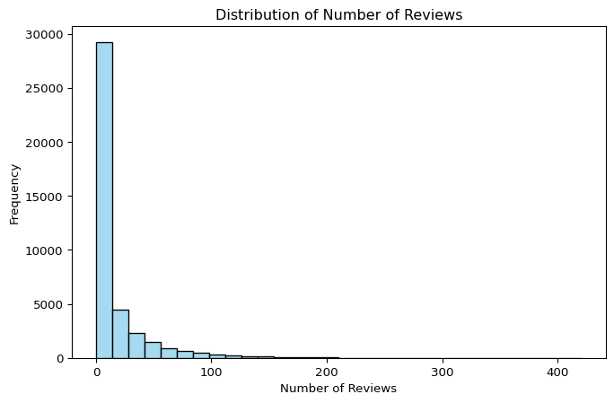

[output not shown]